# Experimental Design and Probability

## Two-way factorial anova

response ~ constant + A + B + A*B + error

\[ \begin{aligned} y_{ij} = \mu + A_i + B_j + (AB)_{ij} + \epsilon_{ij} \\ \end{aligned} \]

- \(\mu\) = population mean across treatments
- \(A\) = treatment A, with levels \(i\)
- \(B\) = tratment B, with levels \(j\)
- \((AB)_{ij}\) = interaction betwen treatment A and B

Factors A and B are considered the *main* effects of interest

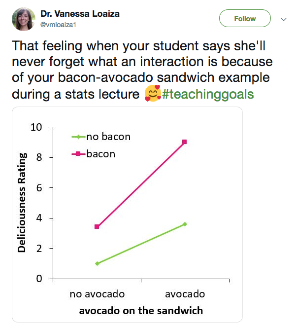

Draw *your* avocado x bacon plot. Then discuss with neighbor.

## Exercise

Analyze and interpret the class avocado-bacon data!

```r
dat <- read_csv(paste(repo_url,
                      "class_data_avocado_bacon.csv", sep = ""))
dat_long <- dat %>%
  gather(key = treatment, value = tastiness, a0_b0:a1_b1) %>%
  mutate(avocado = ifelse(grepl("a0", treatment) == TRUE,
                          "no avocado", "avocado"),
         bacon = ifelse(grepl("b0", treatment) == TRUE,
                        "no bacon", "bacon"))

ggplot(dat_long, aes(treatment, tastiness)) + geom_boxplot()
ggplot(dat_long, aes(avocado, tastiness, fill = bacon)) + geom_boxplot()
```

## Random avocado and bacon data

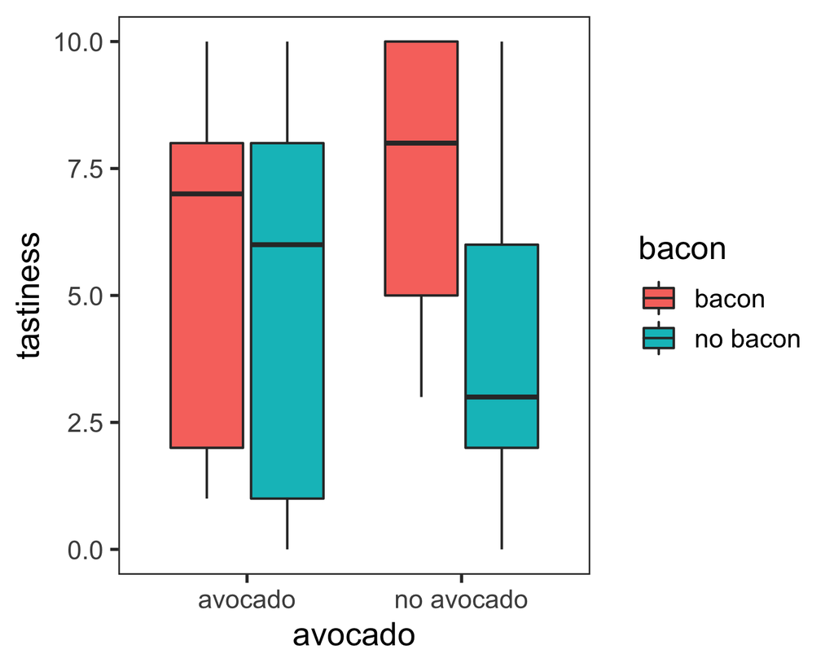

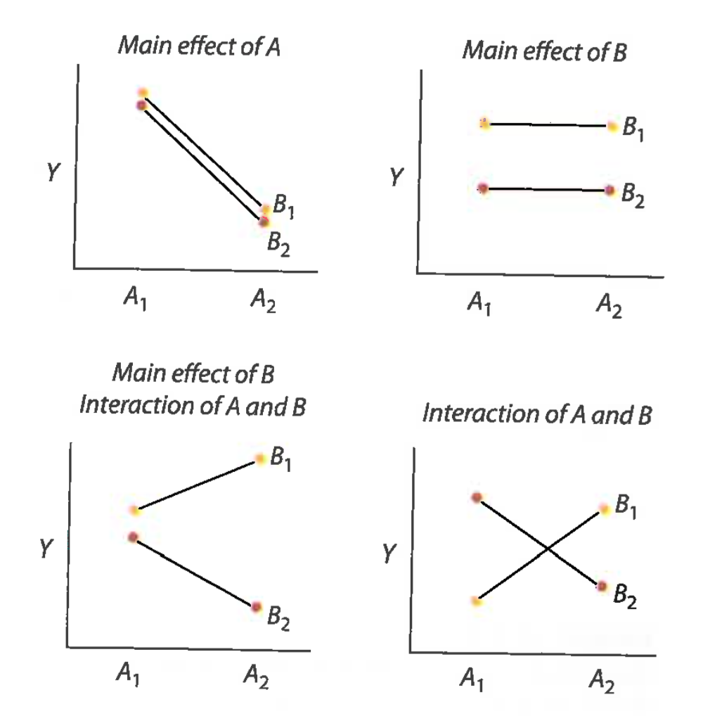

*Whitlock & Schluter 2015*

In a factorial design, *every level of one factor is present in combination with every level of the other factor(s)*.

Not true for a nested design.

**Sketch a crossed vs nested design**

Factor 1: 2 levels (A, B)  
Factor 2: 4 levels, (a, b, c, d)  
n = 4 replicates per factor combination

In a factorial design, *every level of one factor is present in combination with every level of the other factor(s)*.

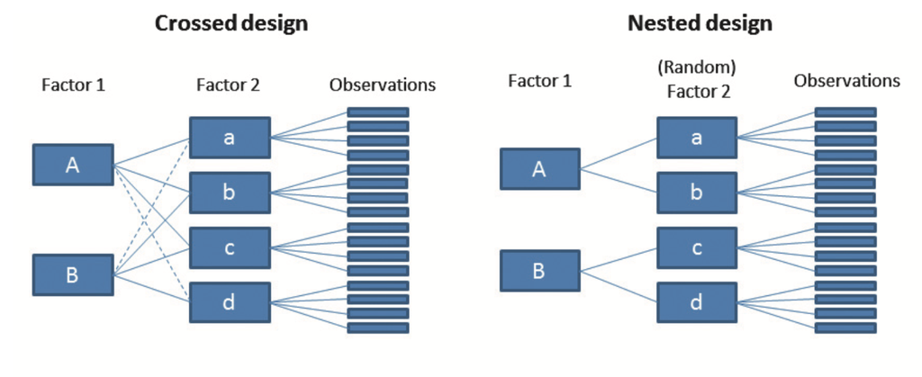

Factor 1: 2 levels (A, B)  
Factor 2: 4 levels, (a, b, c, d)  
n = 4 replicates per factor combination

*Schielzeth & Nakagawa 2013*

## Degrees of freedom

| Source | df |
| --- | --- |
| Among \(A_i\) | *a -1* |
| Among \(B_j\) | *b - 1* |
| Interaction \((AxB)_{ij}\) | *(a-1)(b-1)* |
| Within | *ab(n-1)* |
| Total | *abn - 1* |

## Assumptions

- Errors \(\epsilon_{ij}\) are independent
- Within each combination of factors A & B, errors \(\epsilon_{ij}\) are distributed normally and have equal variance
- ANOVA and F-test assume *balanced* data

## Types of factorial ANOVA

Model 1: all factors are fixed

Model 2: all factors are random

Model 3: one factor fixed, one factor random (at least)

### Model 1, 2 or 3? Consequences for F-ratio

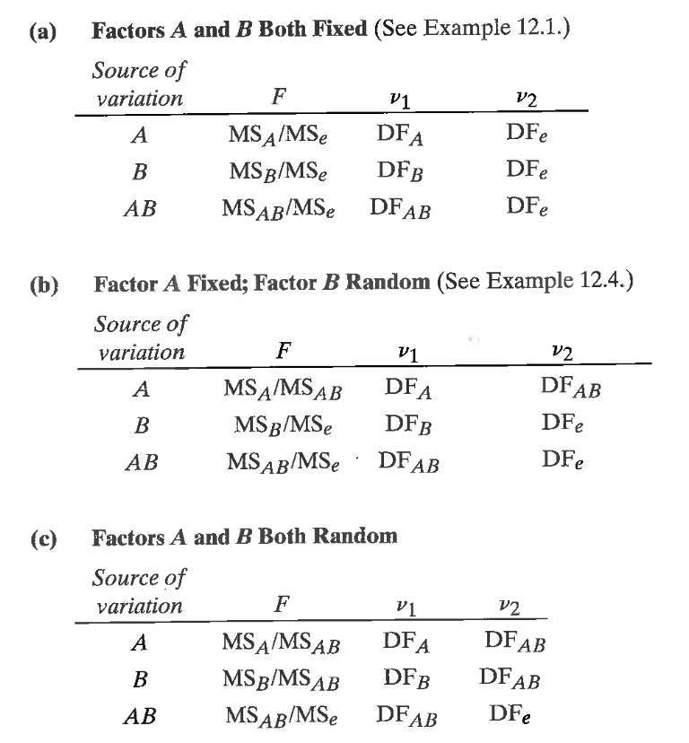

*Zar 2010*

## Factorial ANOVA: example

How do small grazers (limpets and snails) affect the abundance of *Mazzaella* at two different tidal heights?

Factor A: Herbivore treatment

- control (no copper fencing)
- herbivore exclusion (copper fencing)
- a = 2

Factor B: Tidal height

- mid-intertidal zone
- low-intertidal zone
- b = 2

Reponse: percent cover of algae (square-root transformed)

- n = 16 per treatment combination

Fixed or random effects?

## Load the data

```r
# Packages
library(tidyverse); library(broom)
theme_set(theme_bw(base_size = 14) +
            theme(panel.grid = element_blank()))

# Set the web address where R will look for files from this repository
repo_url <- "https://raw.githubusercontent.com/elahi/xdp/master/data/"
dat <- read_csv(paste(repo_url,
                      "chap18e3IntertidalAlgae.csv", sep = ""))
dat <- dat %>%
  mutate(herbivores = ifelse(herbivores == "minus",
                             "absent", "present"), # renaming levels
         herbivores = as.factor(herbivores),
         height = as.factor(height))
```

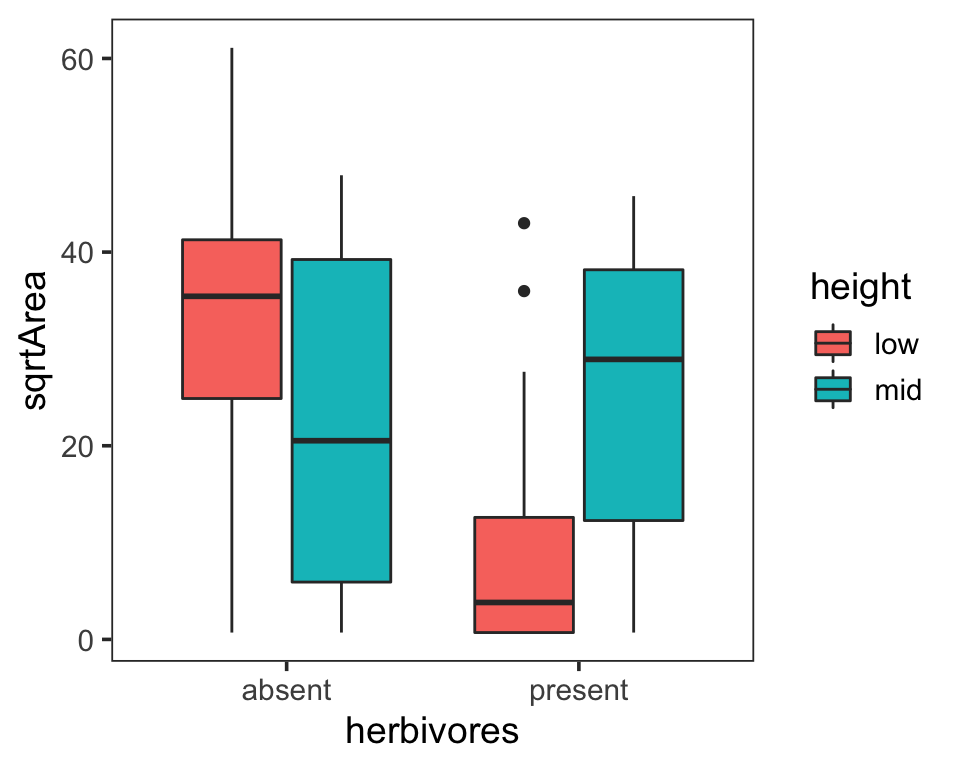

```r
ggplot(dat, aes(herbivores, sqrtArea, fill = height)) + geom_boxplot()
```

\[ \begin{aligned} \text{algae} = \mu + \text{herbivores} + \text{height} + \text{herbivores x height} \\ \end{aligned} \]

```r
m0 <- lm(sqrtArea ~ herbivores + height, data = dat)
m1 <- lm(sqrtArea ~ herbivores + height + herbivores:height, data = dat)
m1 <- lm(sqrtArea ~ herbivores * height, data = dat)
```

### Always check to make sure that the F-ratio is calculated appropriately!

```r
tidy(anova(m0))
```

```
## # A tibble: 3 x 6
##   term          df   sumsq meansq statistic p.value
##   <chr>      <int>   <dbl>  <dbl>     <dbl>   <dbl>
## 1 herbivores     1  1512.  1512.      5.46   0.0227
## 2 height         1    89.0   89.0     0.321  0.573
## 3 Residuals     61 16887.   277.     NA     NA
```

```r
tidy(anova(m1))
```

```
## # A tibble: 4 x 6
##   term                 df   sumsq meansq statistic  p.value
##   <chr>             <int>   <dbl>  <dbl>     <dbl>    <dbl>
## 1 herbivores            1  1512.  1512.      6.36   0.0144
## 2 height                1    89.0   89.0     0.374  0.543
## 3 herbivores:height     1  2617.  2617.     11.0    0.00155
## 4 Residuals            60 14271.   238.     NA     NA
```

```r
tidy(m0)
```

```
## # A tibble: 3 x 5
##   term              estimate std.error statistic  p.value
##   <chr>                <dbl>     <dbl>     <dbl>    <dbl>
## 1 (Intercept)          26.5       3.60     7.36  5.53e-10
## 2 herbivorespresent    -9.72      4.16    -2.34  2.27e- 2
## 3 heightmid             2.36      4.16     0.567 5.73e- 1
```

```r
tidy(m1)
```

```
## # A tibble: 4 x 5
##   term                        estimate std.error statistic  p.value
##   <chr>                          <dbl>     <dbl>     <dbl>    <dbl>
## 1 (Intercept)                     32.9      3.86      8.54 5.98e-12
## 2 herbivorespresent              -22.5      5.45     -4.13 1.15e- 4
## 3 heightmid                      -10.4      5.45     -1.91 6.05e- 2
## 4 herbivorespresent:heightmid     25.6      7.71      3.32 1.55e- 3
```

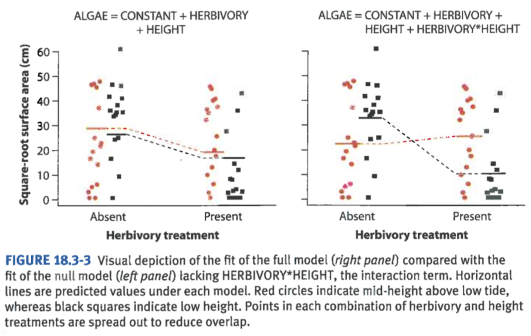

```
##                          term  estimate
## 1                 (Intercept)  32.91450
## 2           herbivorespresent -22.51075
## 3                   heightmid -10.43090
## 4 herbivorespresent:heightmid  25.57809
```

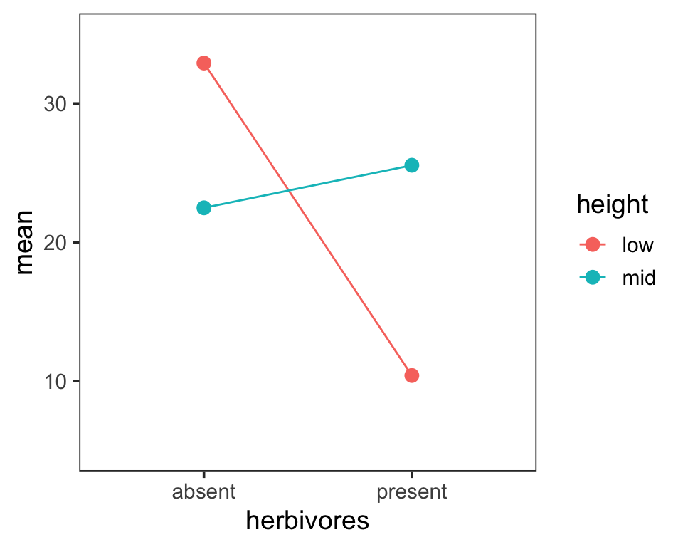

## Model diagnostics

Check that residuals, within treatment combinations,

- have a nearly normal distribution
- no pattern (trend, unequal variance)

```r
par(mfrow = c(2,2)); plot(m1)
```

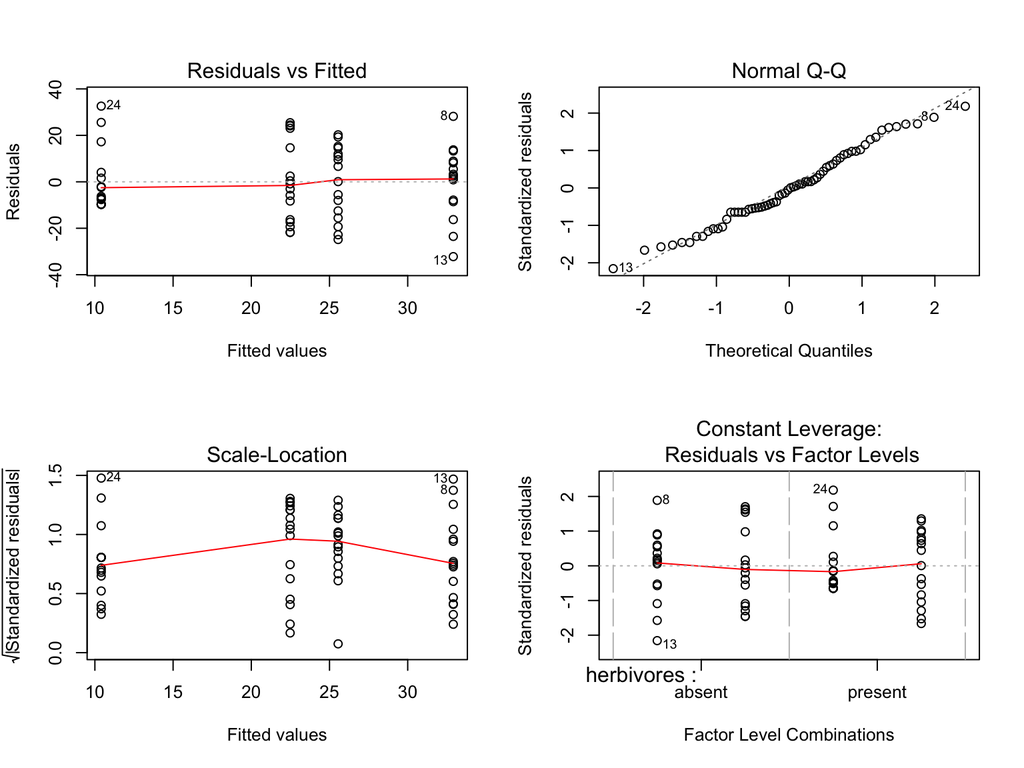

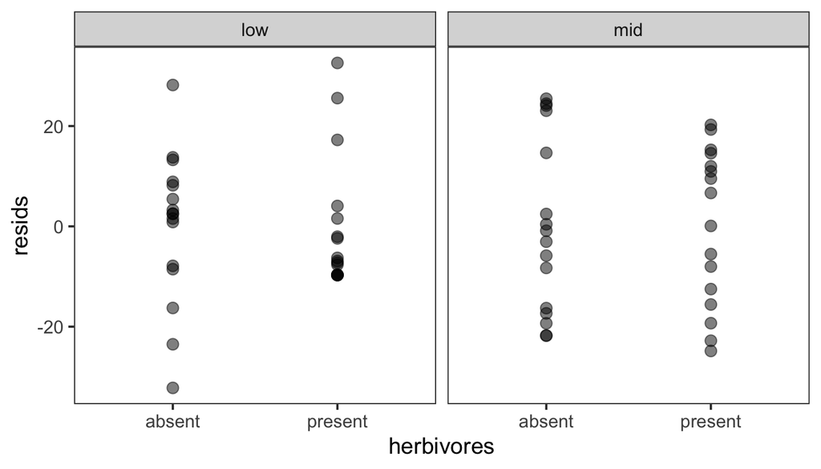

```r
dat$resids <- m1$residuals
ggplot(dat, aes(herbivores, resids)) +
  geom_point(alpha = 0.5, size = 3) + facet_wrap(~ height)
```

## Class wrap-up

1. Practice the analyses (factorial, nested, rcb anova)
2. Teaching evaluations on Canvas!
3. After you complete evals, pick up the final exam from Nicole. Take-home final is an independent project - if you have questions, ask Robin (not Nicole). If I can answer it, and the question is broadly relevant, I will send an announcement on Canvas so that everyone benefits.